# Homework #2

Connor Hergenreter

January 26, 2019

## R commands

Question 1.

```r
cel <- (c(15, -10) - 32) * (5/9)
cel
```

```
## [1]  -9.444444 -23.333333
```

Question 2.

```r
vec200 <- rep(c(1, 0), 100)
vec200
```

```
##   [1] 1 0 1 0 1 0 1 0 1 0 1 0 1 0 1 0 1 0 1 0 1 0 1 0 1 0 1 0 1 0 1 0 1 0 1
##  [36] 0 1 0 1 0 1 0 1 0 1 0 1 0 1 0 1 0 1 0 1 0 1 0 1 0 1 0 1 0 1 0 1 0 1 0
##  [71] 1 0 1 0 1 0 1 0 1 0 1 0 1 0 1 0 1 0 1 0 1 0 1 0 1 0 1 0 1 0 1 0 1 0 1
## [106] 0 1 0 1 0 1 0 1 0 1 0 1 0 1 0 1 0 1 0 1 0 1 0 1 0 1 0 1 0 1 0 1 0 1 0
## [141] 1 0 1 0 1 0 1 0 1 0 1 0 1 0 1 0 1 0 1 0 1 0 1 0 1 0 1 0 1 0 1 0 1 0 1
## [176] 0 1 0 1 0 1 0 1 0 1 0 1 0 1 0 1 0 1 0 1 0 1 0 1 0
```

Question 3.

```r
perfSquareNum <- 1
numPerfect <- 0
while (perfSquareNum <= 1001) {
  if ((perfSquareNum * perfSquareNum)   <=1001) {
    numPerfect <- (numPerfect + 1)
  }
  perfSquareNum <- (perfSquareNum + 1)
}
numPerfect
```

```
## [1] 31
```

## Cars and mileage

Question 1.

```r
library(ggplot2)
top3 <- head(mpg[order(-mpg$hwy),], n = 3)
top3
```

```
## # A tibble: 3 x 11
##   manufacturer model  displ  year   cyl trans drv     cty   hwy fl    class
##   <chr>        <chr>  <dbl> <int> <int> <chr> <chr> <int> <int> <chr> <chr>
## 1 volkswagen   jetta    1.9  1999     4 manu~ f        33    44 d     comp~
## 2 volkswagen   new b~   1.9  1999     4 manu~ f        35    44 d     subc~
## 3 volkswagen   new b~   1.9  1999     4 auto~ f        29    41 d     subc~
```

What are the top three cars by highway milage using the dataframe provided by ggplot? The answer for this question can be obtained by ordering the set by descending highway milage. The top three entries can be taken by using head(). By printing the top3 value we can see the jetta, new beetle, and new beetle as the top three.

Question 2.

```r
numCompact <- length(unique(mpg[["model"]]))
numCompact
```

```
## [1] 38
```

The question is to find the count of unique models in the mpg set. Simply take the length of unique values in the model column from the mpg dataframe. The answer to this question is 38.

Question 3.

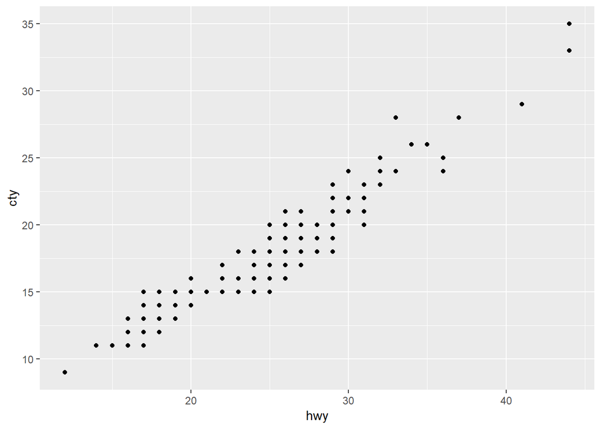

```r
ggplot(mpg, aes(x=hwy, y=cty)) + geom_point()
```

Why are there so few points on this plot compared to all the entries in the mpg dataframe? All the points are contained in this graph. The reason all cannot be seen is that they are being plotted over eachother. Many points are placed in the same location.

Quesion 4.

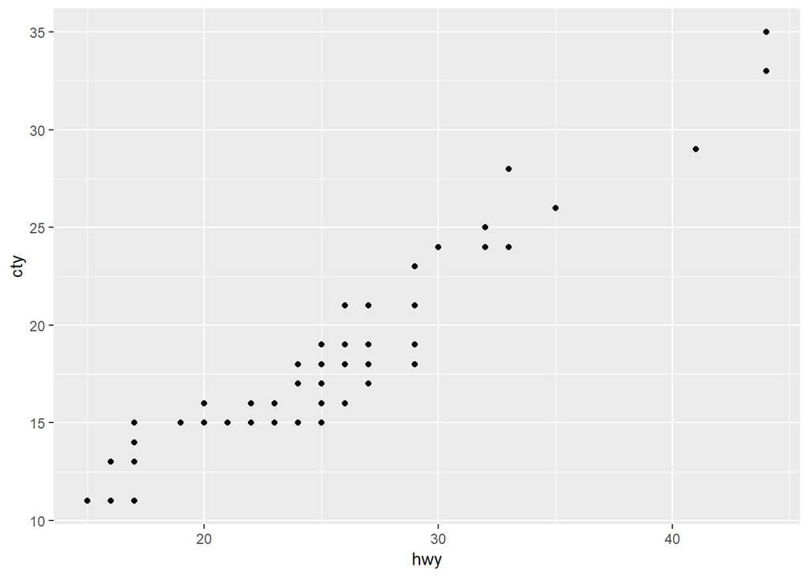

```r
mpg1999 <- mpg[which(mpg$year == 1999),]
ggplot(mpg1999, aes(x=hwy, y=cty)) + geom_point()
```

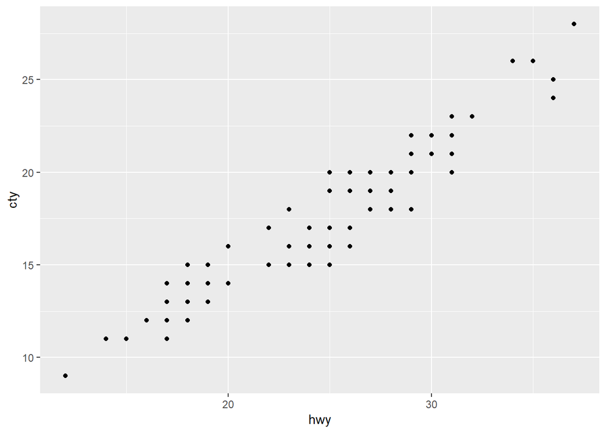

```r
mpg2008 <- mpg[which(mpg$year == 2008),]
ggplot(mpg2008, aes(x=hwy, y=cty)) + geom_point()
```